# Genome-wide methylation analysis report

# Genome-wide methylation analysis report

- study: Pleural cfDNAm analysis of meso_maligvariable
- author: Paul Yousefi
- date: 08 October, 2026

## Parameters

```
## $sig.threshold
## [1] 2.121143e-07
##
## $max.plots
## [1] 10
##
## $qq.inflation.method
## [1] "median"
##
## $practical.threshold
## [1] 9.899158e-05
```

## Sample characteristics

For continuous or ordinal variables, the “mean” column provides the mean and the “sd/%” column the standard deviation of the variable. For categorical variables, the “mean” column provides the number of samples with the given “value” and the “sd/%” column the percentage of samples with the given “value”.

| variable | value | mean | sd.. |
| --- | --- | --- | --- |
| meso_malig |  | 0.3529412 | 0.4792964 |
| sv1 |  | 4.742986e-19 | 0.07692308 |
| sv2 |  | -1.057815e-18 | 0.07692308 |
| sv3 |  | -2.008963e-19 | 0.07692308 |
| sv4 |  | 1.838042e-18 | 0.07692308 |
| sv5 |  | -7.633262e-19 | 0.07692308 |
| sv6 |  | 1.851315e-18 | 0.07692308 |
| sv7 |  | -1.530658e-18 | 0.07692308 |
| sv8 |  | -3.326787e-18 | 0.07692308 |
| sv9 |  | -2.898272e-15 | 0.07692308 |
| sv10 |  | -1.608725e-13 | 0.07692308 |

## Covariate associations

### Covariate sv1

statistics

| var1 | var2 | F | p-value | R | p-value |
| --- | --- | --- | --- | --- | --- |
| meso_malig | sv1 | 1.12039 | 0.291354 | 0.0601989 | 0.4355003 |

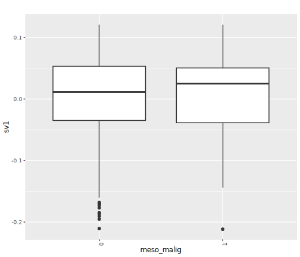

### Covariate sv2

statistics

| var1 | var2 | F | p-value | R | p-value |
| --- | --- | --- | --- | --- | --- |
| meso_malig | sv2 | 0.0003824 | 0.9844223 | -0.0657171 | 0.3945219 |

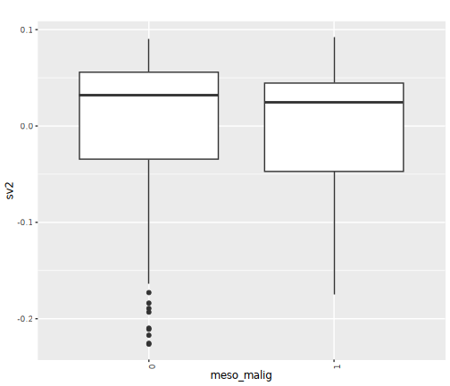

### Covariate sv3

statistics

| var1 | var2 | F | p-value | R | p-value |
| --- | --- | --- | --- | --- | --- |
| meso_malig | sv3 | 5.092328 | 0.0253209 | -0.1249127 | 0.1045874 |

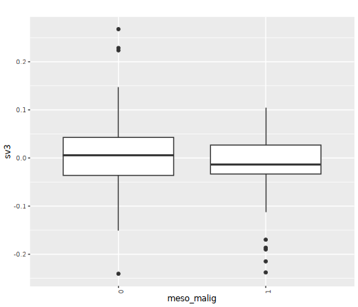

### Covariate sv4

statistics

| var1 | var2 | F | p-value | R | p-value |
| --- | --- | --- | --- | --- | --- |
| meso_malig | sv4 | 1.147286 | 0.2856544 | -0.0709845 | 0.3576472 |

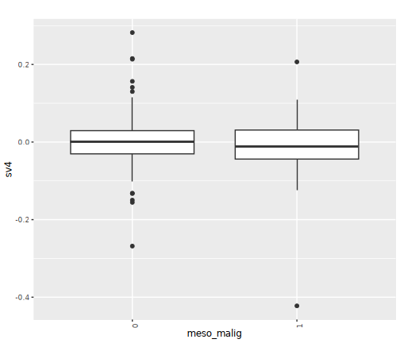

### Covariate sv5

statistics

| var1 | var2 | F | p-value | R | p-value |
| --- | --- | --- | --- | --- | --- |
| meso_malig | sv5 | 0.5559127 | 0.4569537 | 0.0464033 | 0.5479165 |

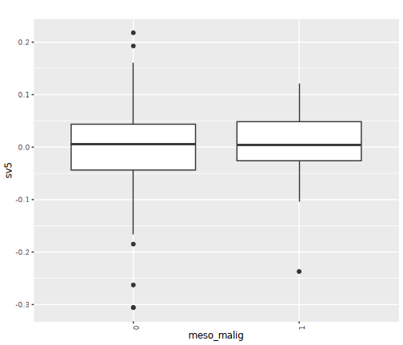

### Covariate sv6

statistics

| var1 | var2 | F | p-value | R | p-value |
| --- | --- | --- | --- | --- | --- |
| meso_malig | sv6 | 0.08258 | 0.7741852 | 0.001505 | 0.98446 |

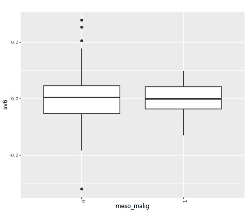

### Covariate sv7

statistics

| var1 | var2 | F | p-value | R | p-value |
| --- | --- | --- | --- | --- | --- |
| meso_malig | sv7 | 1.828139 | 0.1781649 | 0.1351967 | 0.0787776 |

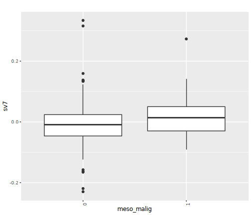

### Covariate sv8

statistics

| var1 | var2 | F | p-value | R | p-value |
| --- | --- | --- | --- | --- | --- |
| meso_malig | sv8 | 0.175566 | 0.675747 | 0.008779 | 0.9095375 |

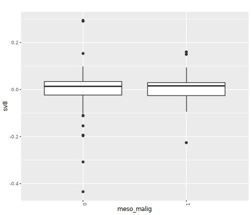

### Covariate sv9

statistics

| var1 | var2 | F | p-value | R | p-value |
| --- | --- | --- | --- | --- | --- |
| meso_malig | sv9 | 1.85565 | 0.1749513 | 0.0887934 | 0.2495438 |

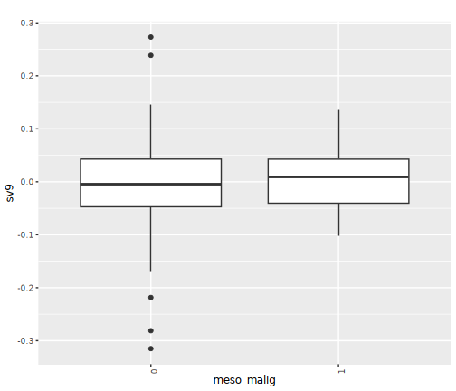

### Covariate sv10

statistics

| var1 | var2 | F | p-value | R | p-value |
| --- | --- | --- | --- | --- | --- |
| meso_malig | sv10 | 0.0003553 | 0.984984 | -0.0408851 | 0.5965525 |

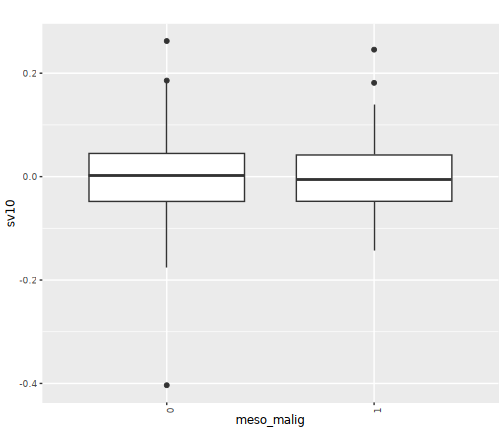

## QQ plots

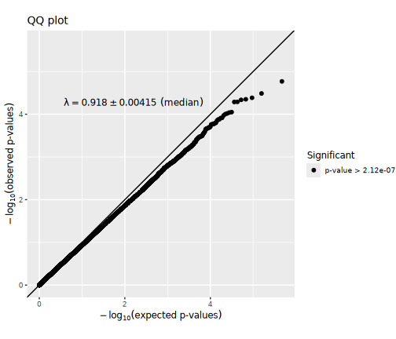

## Manhattan plots

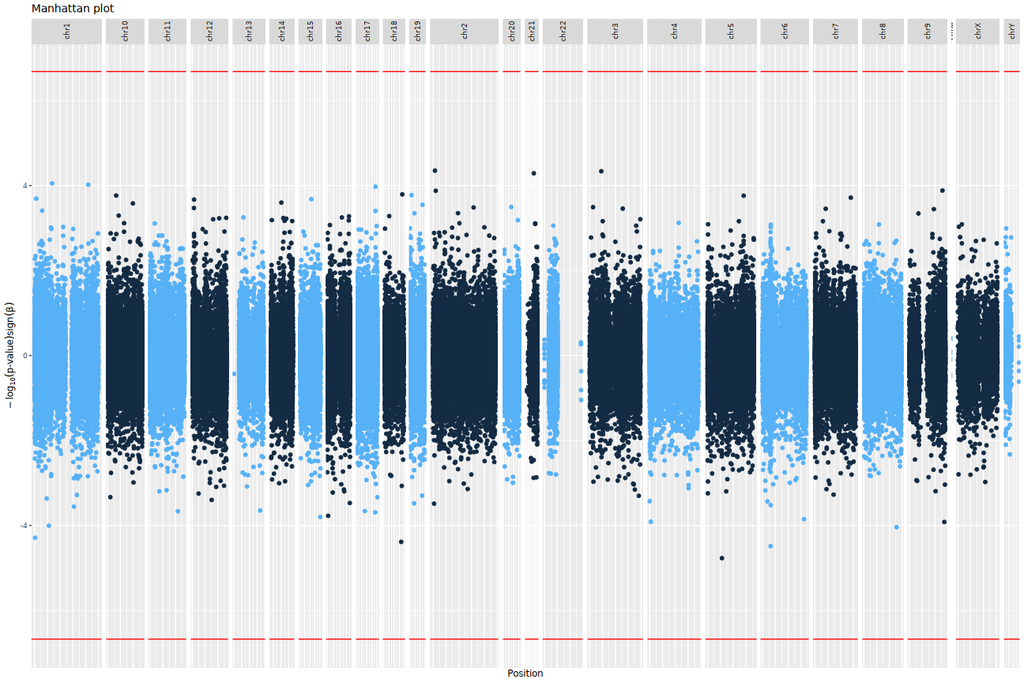

## Significant CpG sites

There were 0 CpG sites with association p-values < 2.1211427 × 10<sup>-7</sup>. These are listed in the file associations.csv.

Below are the 10 CpG sites with association p-values < 9.899158 × 10<sup>-5</sup> in the regression model.

|  | chromosome | position | estimate | p.value | p.adjust |
| --- | --- | --- | --- | --- | --- |
| cg02380637 | chr2 | 7171893 | 0.0694795 | 4.47e-05 | 1 |
| cg25192855 | chr1 | 209979283 | 0.0719206 | 9.57e-05 | 1 |
| cg00049278 | chr1 | 2004925 | -0.0526016 | 5.13e-05 | 1 |
| cg22082780 | chr1 | 68452167 | 0.0927511 | 8.91e-05 | 1 |
| cg05080926 | chr6 | 31129626 | -0.0506822 | 3.26e-05 | 1 |
| cg25883066 | chr8 | 127647405 | -0.0534320 | 9.13e-05 | 1 |
| cg09639152 | chr3 | 45078075 | 0.0634389 | 4.61e-05 | 1 |
| cg13333275 | chr18 | 68045800 | -0.0504472 | 4.12e-05 | 1 |
| cg17458922 | chr21 | 32932343 | 0.0701989 | 5.16e-05 | 1 |
| cg01164141 | chr5 | 55977468 | -0.0630376 | 1.70e-05 | 1 |

Plots of these sites follow, one for each covariate set. “p[lm]” denotes the p-value obtained using a linear model and “p[beta]” the p-value obtained using beta regression.

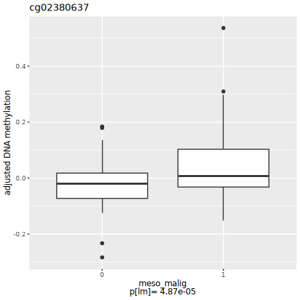

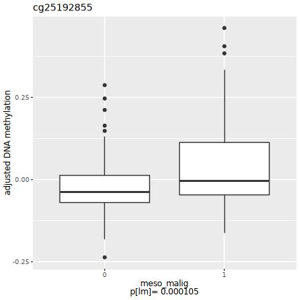

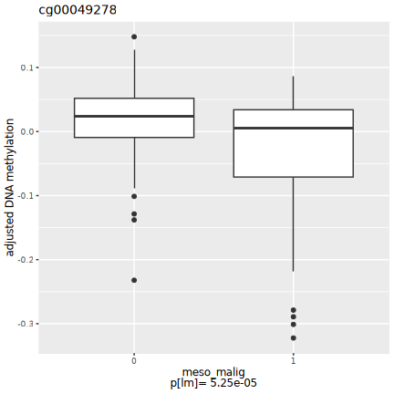

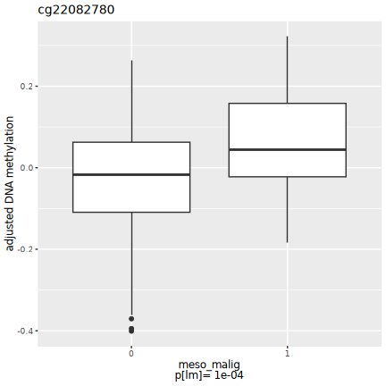

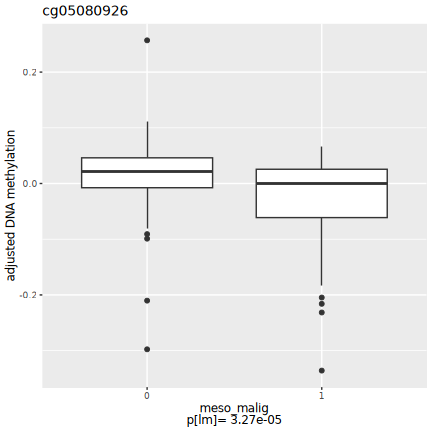

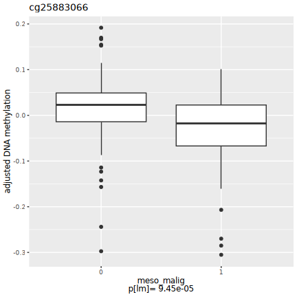

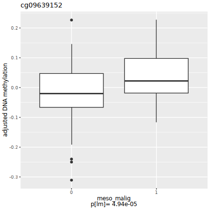

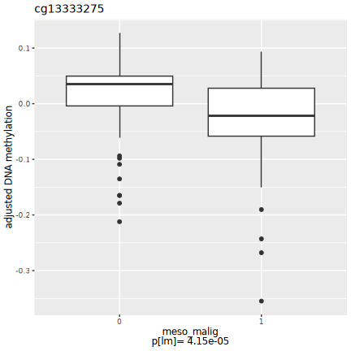

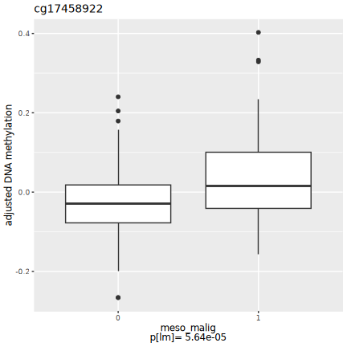

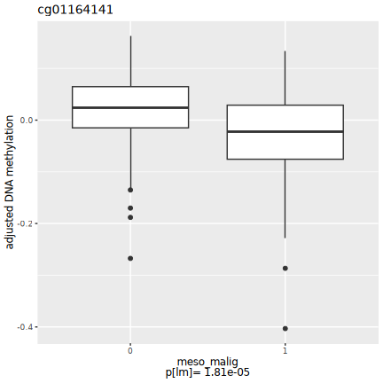

## Selected CpG sites

Number of CpG sites selected: 0.

| chromosome | position | estimate | p.value | p.adjust |
| --- | --- | --- | --- | --- |